# Praca domowa 2

Filip Kowalczyk

## Dane

Dane wykorzystane w Pracy domowej 2 są związane z kampaniami marketingu bezpośredniego portugalskiej instytucji bankowej. Kampanie marketingowe opierały się na rozmowach telefonicznych. Często wymagany był więcej niż jeden kontakt z tym samym klientem, aby uzyskać dostęp do tego, czy produkt (lokata bankowa) zostanie (lub nie) subskrybowany. Opis wszystkich kolumn znajduje się również w pliku `README.md`.

#### Dane klienta banku

| Zmienna | Opis |
| --- | --- |
| **age** | wiek |
| **job** : admin., unknown, unemployed, management, housemaid, entrepreneur, student, blue-collar, self-employed, retired, technician, services | administrator, nieznany, bezrobotny, kierownictwo, pokojówka, przedsiębiorca, student, pracownik fizyczny, samozatrudniony, emeryt, technik, usługi |
| **marital** : married, divorced, single; note: divorced means divorced or widowed) | żonaty/zamężna, rozwiedzion_, kawaler/panna; uwaga: rozwiedzion_ oznacza rozwiedzion_ lub owdowiał_ |
| **education** : unknown, secondary, primary, tertiary | nieznane, średnie, podstawowe, wyższe |
| **default** : yes, no | czy kredyt jest niespłacany : tak, nie |
| **balance** : average yearly balance, in euros | średnie roczne saldo w euro |
| **housing** : has housing loan? yes, no | czy posiada kredyt mieszkaniowy? tak, nie |
| **loan** : has personal loan? yes, no | ma pożyczkę osobistą? tak, nie |

#### Dane związane z ostatnim kontaktem w bieżącej kampanii

| Zmienna | Opis |
| --- | --- |
| **contact** : unknown, telephone, cellular | nieznany, telefon, komórkowy |
| **day** : last contact day of the month | dzień miesiąca ostatniego kontaktu |
| **month** : last contact month of year, jan, feb, mar, …, nov, dec | miesiąc ostatniego kontaktu w roku, styczeń, luty, marzec, …, listopad, grudzień |
| **duration** : last contact duration, in seconds | czas trwania ostatniego kontaktu w sekundach |

## Zadanie 1

Weźmy pod uwagę zawody (`job`) klientów banku. Który zawód zacząco wyróżnia się w posiadaniu kredytu mieszkaniowego lub pożyczki osobistej?

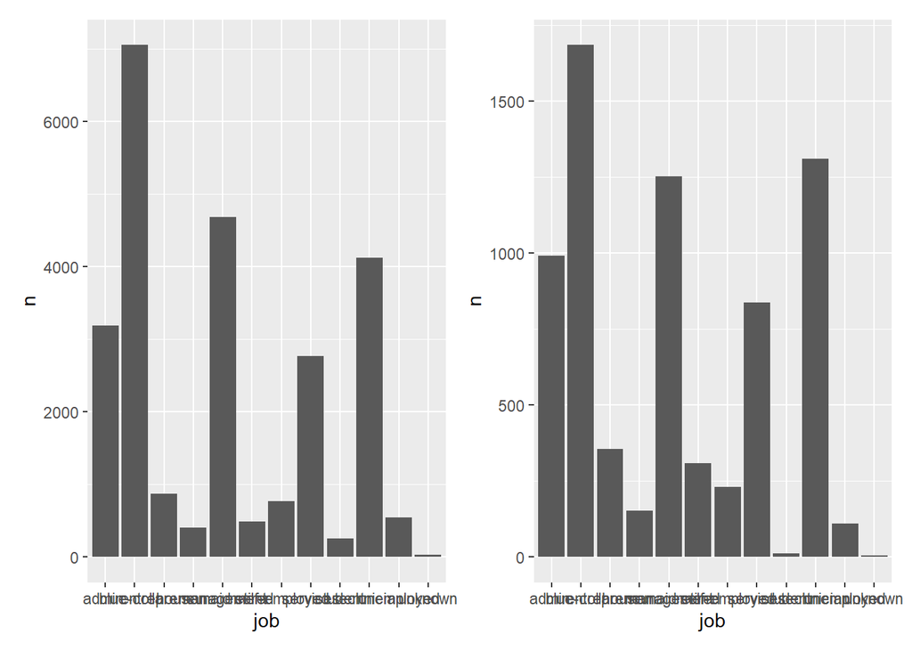

```r
t1<-df %>%
  filter(housing=="yes") %>%
  group_by(job) %>%
  summarise(n=n())
p1<-ggplot(t1,aes(x=job,y=n))+geom_col()

t2<-df %>%
  filter(loan=="yes") %>%
  group_by(job) %>%
  summarise(n=n())
p2<-ggplot(t2,aes(x=job,y=n))+geom_col()

p1+p2
```

**Komentarz:** W posiadaniu kredytu jak i pożyczki znacząco wyróżnia się blue-collar, co w uwzględnieniu sumarycznego rozkładu przełożyłoby się na jeszcze wyraźniejszą różnicę.

## Zadanie 2

Wybierając klientów, którzy mają nieznany sposób kontaktu (`contact`). Jak rozkłada się ich wiek w podziale na status związku?

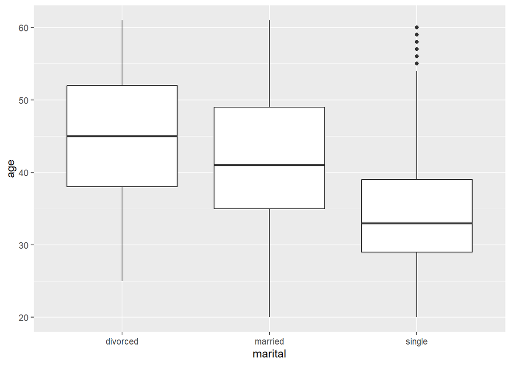

```r
t11<-df %>%
  filter(contact=="unknown")
p11<-ggplot(t11,aes(x=marital,y=age))+geom_boxplot()
p11
```

**Komentarz:** Pośród tych klientów najmłodsi okazali się single, potem poślubieni, a najstarsi rozwiedzeni.

## Zadanie 3

Jaka jest różnica pomiędzy średnim rocznym saldem w euro w zależności od wykształcenia i tego czy kredyt jest niespłacany?

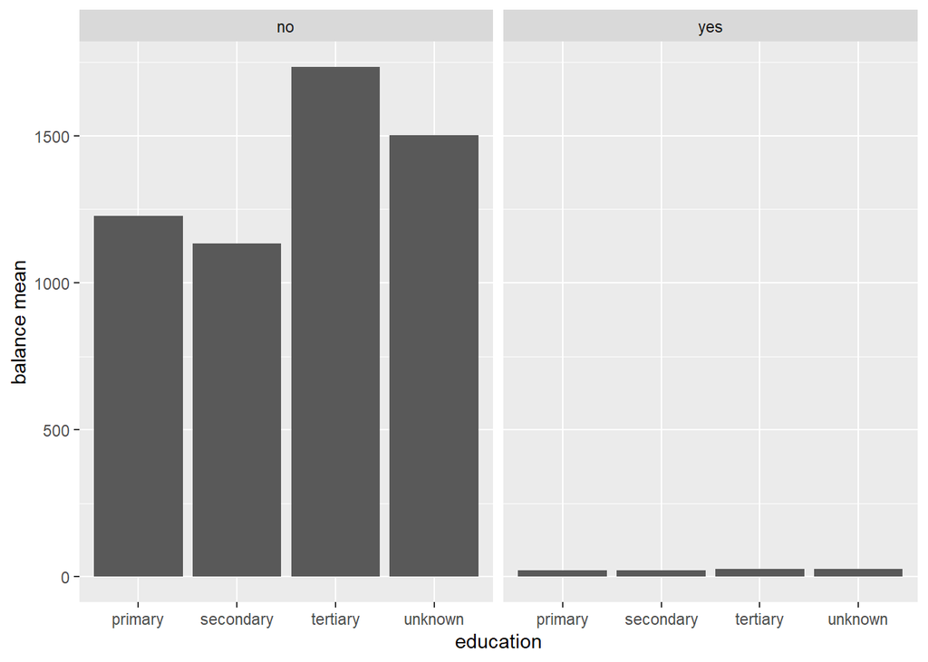

```r
t111<-df %>%
  group_by(education) %>%
  mutate(m=mean(balance),n0=n()) %>%
  select(m,education,default,n0,balance)
p111<-ggplot(t111,aes(x=education,y=m/n0))+geom_col()+facet_wrap(~default)+labs(y="balance mean")
p111
```